# Review - Assigment - Naive Bayes DIY

Anita Munar Author

Linh Vo Reviewer

15 March, 2023

# Business Understanding

In this assignment, my task is to build a model that can identify fake news, based on manually categorized sentiment data. I will make use of the Naive Bayes function.

**Review**: `ggplot2` is included in `tidyverse`. So you only need to load one package `tidyverse`. `wordcloud` package is loaded two times.

```r
url <- "https://raw.githubusercontent.com/HAN-M3DM-Data-Mining/assignments/master/datasets/NB-fakenews.csv"
rawDF <- read_csv(url)
View(rawDF)
```

I start importing the dataset, for which I used the raw version of the csv file from the github environment. Sadly, I do not yet know how to connect my repository to R.

# Data Understanding

```r
head(rawDF)
```

[output not shown]

```r
str(rawDF)
```

[output not shown]

```r
rawDF$label <- rawDF$label %>% factor %>% relevel("1")
class(rawDF$label)
```

```
[1] "factor"
```

```r
rawDF$label <- rawDF$label %>% factor %>% relevel("0")
class(rawDF$label)
```

```
[1] "factor"
```

**Review**: for data understanding, I think it’s better if you list dataset description for each variable then everyone when reading your assignment can know which variable means. For example, `label` variable a label marks the article as potentially unreliable, “1” means unreliable and “0” means reliable. Then I can keep track what you do with these numbers. Review: I think you misunderstand the usage of the function `relevel`. This function will prioritize the level of a factor, the others are moved down. So you only use `relevel` function for one value. Here you relevel for two values in a column that has two values, so which one will be priortised??? For this, I suggest relevel with the value “1” - unreliable articles

After releveling 0 and 1 labels as factors with the command above and getting the correct response, we can proceed.

```r
fake <- rawDF %>% filter(label == "1")
real <- rawDF %>% filter(label == "0")
```

I assigned the variables “fake” for fake news, and “real” for actual news, with the filer function connecting it to labels 0 and 1.

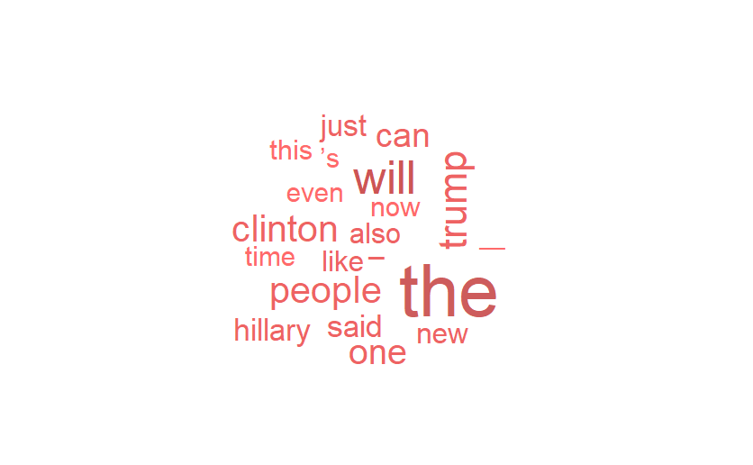

```r
wordcloud(fake$text, max.words = 20, scale = c(4, 0.8), colors= c("indianred1","indianred2","indianred3","indianred"))
```

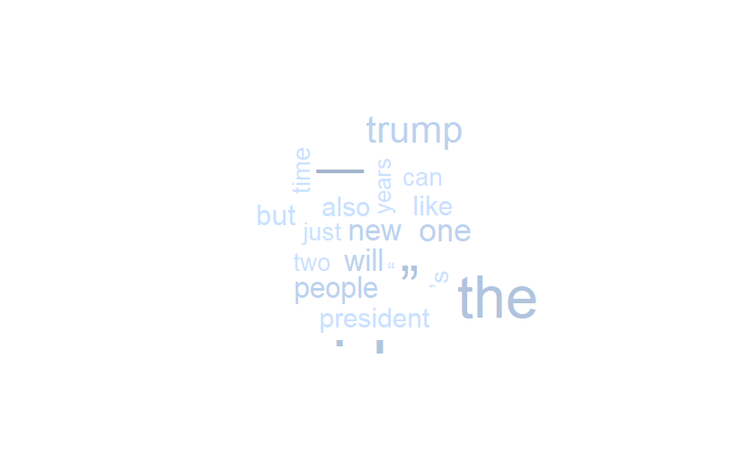

```r
wordcloud(real$text, max.words = 20, scale = c(4, 0.8), colors= c("lightsteelblue1","lightsteelblue2","lightsteelblue3","lightsteelblue"))
```

# Data Preparation

With the corpus() function, we create a collection for the text data.

```r
rawCorpus <- Corpus(VectorSource(rawDF$text))
inspect(rawCorpus[1:3])
```

After the computer takes its time to create the raw corpus, we see that the data must be cleaned. For this, we make a new variable that applies the tm_map() functions to remove any numbers, punctuation, stopwords and white spaces.

```r
cleanCorpus <- rawCorpus %>% tm_map(tolower) %>% tm_map(removeNumbers)
cleanCorpus <- cleanCorpus %>% tm_map(tolower) %>% tm_map(removeWords, stopwords()) %>% tm_map(removePunctuation)
cleanCorpus <- cleanCorpus %>% tm_map(stripWhitespace)
```

The error comes up as seen in class:

```
transformation drops documents
```

```r
tibble(Raw = rawCorpus$content[1:3], Clean = cleanCorpus$content[1:3])
```

| Raw | Clean |
| --- | --- |
| House Dem Aide: We Didn’t Even See Comey’s Letter Until Jason Chaffetz Tweeted It By Darrell Lucus on October 30, 2016 Subscribe Jason Chaffetz on the stump in American Fork, Utah ( image courtesy Mic… | house dem aide didn’t even see comey’s letter jason chaffetz tweeted darrell lucus october subscribe jason chaffetz stump american fork utah image courtesy michael jolley available creative commons li… |
| Ever get the feeling your life circles the roundabout rather than heads in a straight line toward the intended destination? [Hillary Clinton remains the big woman on campus in leafy, liberal Wellesley… | ever get feeling life circles roundabout rather heads straight line toward intended destination hillary clinton remains big woman campus leafy liberal wellesley massachusetts everywhere else votes lik… |
| Why the Truth Might Get You Fired October 29, 2016 \nThe tension between intelligence analysts and political policymakers has always been between honest assessments and desired results, with the latte… | truth might get fired october tension intelligence analysts political policymakers always honest assessments desired results latter often overwhelming former iraq war writes lawrence davidson lawrence… |

Using a tibble, I can check how well I cleaned the raw corpus data.

Next, I create a new DTM (Document Term Matrix) from the cleanCorpus data, which will detect all words and arrange them into their own columns per each word. In large text datasets like the one we are working with this part takes time for the computer to load.

```r
cleanDTM <- cleanCorpus %>% DocumentTermMatrix
inspect(cleanDTM)
```

```
<<DocumentTermMatrix (documents: 20800, terms: 251790)>>
Non-/sparse entries: 5799371/5231432629
Sparsity           : 100%
Maximal term length: 242
Weighting          : term frequency (tf)
Sample             :
       Terms
Docs      —  ’s   “  ” new one people said trump will
  10205 185 202  11 27  27  45     88   65   129   41
  13534   9  82  16  8  15  61    149   16     0  123
  13746 114  31  73 93  27  72     34   24     0   14
  14294   3  30  19  2  15  39     58    4     0   55
  19765   0   0   0  0   0   0      0    0     0    0
  2735    4  62  40 20  17  74     53   17    63  154
  465     2   7 122 31   7  20     14    5     0   16
  5093    3  82  13  3  19  59    105   10     1   61
  7531    1  52  14  4  24  62    126   11     1  143
  8720    5  76  24 10  20  45     83   22     0  143
```

We can now inspect the matrix.

[output not shown]

Review: fix the error of the function `cleanDM` to `cleanDTM`. You don’t have to copy the result out, when I run the code, the result will appear.

Now, the testing and training part of the code. First, a random number generator is used.

```r
set.seed(1234)
```

Then the data data must be split into test and training data, 25% and 75% randomly, using the createDataPartition() function.

```r
trainIndex <- createDataPartition(rawDF$label, p = .75,
                                  list = FALSE,
                                  times = 1)
```

Review: there is an error here, I fixed this by relocating the `list` and `times` align vertically with `rawDF$label`

```r
head(trainIndex)
```

```
     Resample1
[1,]         1
[2,]         2
[3,]         3
[4,]         5
[5,]        10
[6,]        11
```

Now, both indices are split to test and training data, we can apply them to the dataset, the corpus, and the DTM.

```r
trainDF <- rawDF[trainIndex, ]
testDF <- rawDF[-trainIndex, ]
trainCorpus <- cleanCorpus[trainIndex]
testCorpus <- cleanCorpus[-trainIndex]
trainDTM <- cleanDTM[trainIndex, ]
testDTM <- cleanDTM[-trainIndex, ]
```

Review: fix the error by adding the substraction sign “-” in front of `trainIndex`

```r
freqWords <- trainDTM %>% findFreqTerms(1000)
trainDTM <-  DocumentTermMatrix(trainCorpus, list(dictionary = freqWords))
testDTM <-  DocumentTermMatrix(testCorpus, list(dictionary = freqWords))
```

Review: fix the the argument inside the function `findFreTerms` from 100000 to 1000. the findFreqTerms functions here is to bound the frequent terms inside the document-term. So the argument “1000” means that only select the terms that have frequent more or equal than “1000”, not the first 1000 most frequent words like you wrote.

```r
convert_counts <- function(x) {
  x <- ifelse(x > 0, 1, 0) %>% factor(levels = c(0,1), labels = c("No", "Yes"))
}
```

```r
nColsDTM <- dim(trainDTM)[2]
trainDTM <- apply(trainDTM, MARGIN = 2, convert_counts)
View(testDTM)
testDTM <- apply(testDTM, MARGIN = 2, convert_counts)
View(testDTM)
head(trainDTM[,1:10])
```

```
    Terms
Docs according actually agency already also  american answer
   1 "Yes"     "Yes"    "Yes"  "Yes"   "Yes" "Yes"    "Yes"
   2 "No"      "No"     "No"   "No"    "No"  "Yes"    "No"
   3 "No"      "No"     "Yes"  "Yes"   "Yes" "Yes"    "Yes"
   4 "Yes"     "No"     "No"   "No"    "No"  "No"     "No"
   5 "Yes"     "No"     "No"   "No"    "Yes" "Yes"    "Yes"
   6 "Yes"     "No"     "Yes"  "No"    "Yes" "No"     "No"
    Terms
Docs anything appear attempt
   1 "Yes"    "Yes"  "Yes"
   2 "No"     "No"   "No"
   3 "Yes"    "No"   "No"
   4 "No"     "No"   "No"
   5 "No"     "No"   "No"
   6 "No"     "No"   "No"
```

# Modelling

After seeing our cleaned trainDTM file, we can apply the nbayes model to use given featres and labels to come up with a model that can identify fake news. Then, we generate the predVec vector for predict(nbayes, testDTM)

```r
nbayesModel <- naiveBayes(trainDTM, trainDF$label, laplace = 1)

predVec <- predict(nbayesModel, testDTM)
```

```r
confusionMatrix(predVec, testDF$label, positive = "1", dnn = c("No", "yes"))
```

```
Confusion Matrix and Statistics

   yes
No     0    1
  0 1719  530
  1  877 2073

               Accuracy : 0.7294
                 95% CI : (0.7171, 0.7414)
    No Information Rate : 0.5007
    P-Value [Acc > NIR] : < 2.2e-16

                  Kappa : 0.4586

 Mcnemar's Test P-Value : < 2.2e-16

            Sensitivity : 0.7964
            Specificity : 0.6622
         Pos Pred Value : 0.7027
         Neg Pred Value : 0.7643
             Prevalence : 0.5007
         Detection Rate : 0.3987
   Detection Prevalence : 0.5674
      Balanced Accuracy : 0.7293

       'Positive' Class : 1
```

The outcome of my NB model is the following:

[output not shown]

Review: I fixed the error from “yes” to “1”. I have a small comment. I don’t know why you use “Yes” and “No” for the `dnn` argument to name the dimensions of the table to compare prediction and the true labels because it doesn’t clearly describe what the values inside means. It should be named “Prediction” and “True”

# Evaluation